# Beach vs. Mountains Preference

Kimberly Carlini

# Introduction

> Over the course of analyzing this data my main goal has evolved as I learned more about data and methods used to create synthetic datasets. Originally, I was confused about what could be found from a synthetic dataset that was so evenly distributed and looked to be very random. However as I got more into the data I found that by visualizing the data I could find that some variables did affect the end preference. This was huge. The main goal of this project is not to make insights that reflect the real world rather look closer into this dataset and essentially disect it to demonstrate the importance of data analytics.

# Summary

> For this project I will be finding what variables affect the end descion of preference over the beach or the mountains by using data vizualizations. By using graphs like barcharts we can see what part of each category chose one location vs. another which will allow us to find where the preference varies between categories/ ranges within a variable. We will also look at what clues we can find that signals that the data is synthetic rather than real data along with how the dataset may have been made. Then using the information we find we will be able to see what factors will lead to a preference towards the mountains in this dataset.

# Purpose

> The main goal of the project is to essentially discect the dataset and find what variables affect the choice between the beach and the mountains as well as find out how this dataset was synthetically made and how we can tell it is synthetic. An important question to be answered is why is the preference so skewed towards the beach and what potential methods were used to create what we find.

## Libraries used

```r
# libraries
library(dplyr)
library(tidyverse)
library(ggplot2)
library(correlation)
```

```r
# Loading in the data set
Beach_vs_mountain <- read.csv("mountains_vs_beaches_preferences.csv")
head(Beach_vs_mountain)
```

|  | Age | Gender | Income | Education_Level | Travel_Frequency | Preferred_Activities | Vacation_Budget | Location | Proximity_to_Mountains | Proximity_to_Beaches | Favorite_Season | Pets | Environmental_Concerns | Preference |
| --- | --- | --- | --- | --- | --- | --- | --- | --- | --- | --- | --- | --- | --- | --- |
| 1 | 56 | male | 71477 | bachelor | 9 | skiing | 2477 | urban | 175 | 267 | summer | 0 | 1 | 1 |
| 2 | 69 | male | 88740 | master | 1 | swimming | 4777 | suburban | 228 | 190 | fall | 0 | 1 | 0 |
| 3 | 46 | female | 46562 | master | 0 | skiing | 1469 | urban | 71 | 280 | winter | 0 | 0 | 1 |
| 4 | 32 | non-binary | 99044 | high school | 6 | hiking | 1482 | rural | 31 | 255 | summer | 1 | 0 | 1 |
| 5 | 60 | female | 106583 | high school | 5 | sunbathing | 516 | suburban | 23 | 151 | winter | 1 | 1 | 0 |
| 6 | 25 | male | 110588 | doctorate | 3 | sunbathing | 2895 | urban | 6 | 47 | fall | 0 | 1 | 0 |

# Data

> due to this data being synthetic it allowed the designer to not include any NA values or inconsistent values which so far has made working with it very nice. Because of this I am able to simply use the dataset as it is. Below I have included a data dictionary to have proper descriptions of each variable, the dimensions so we know what we are working with, As well as a description of summary statistics which will give us a good starting point by giving us a closer look at each variable.

```r
# Dictionary of the features of the data set including: variable name, what that variable is representing, and if its numerical or categorical.

dictionary <- data.frame(
  variable_name = c("Age", "Gender", "Income", "Education_Level", "Travel_Frequency", "Preferred_Activities", "Vacation_Budget", "Location", "Proximity_to_Mountains", "Proximity_to_Beaches", "Favorite_Season", "Pets", "Environmental_Concerns", "Preference"),
  representing = c("Respondent's age", "Respondent's gender", "Respondent's Income", "Respondent's level of education", "Respondent's frequency of travel", "Respondent's preferred activity", "Respondent's vacation budget ($)", "What type of area they live in", "Distance from mountains (mi)", "distance from beaches (mi)", "Respondent's favorite season", "Y/N if they have a pet", "Y/N if they are concerned with the enviroment", "The respondent's choice of preference between beaches vs mountains"),
  Numerical_or_Catagorical = c("N", "C", "N", "C", "N", "C", "N", "C", "N", "N", "C", "C", "C", "C")
)

dictionary
```

| variable_name | representing | Numerical_or_Catagorical |
| --- | --- | --- |
| Age | Respondent's age | N |
| Gender | Respondent's gender | C |
| Income | Respondent's Income | N |
| Education_Level | Respondent's level of education | C |
| Travel_Frequency | Respondent's frequency of travel | N |
| Preferred_Activities | Respondent's preferred activity | C |
| Vacation_Budget | Respondent's vacation budget ($) | N |
| Location | What type of area they live in | C |
| Proximity_to_Mountains | Distance from mountains (mi) | N |
| Proximity_to_Beaches | distance from beaches (mi) | N |

[output cut: 4 more lines]

```r
NA
```

```r
# Dimensions
dim(Beach_vs_mountain)
```

```
[1] 52444    14
```

```r
#Summary Statistics of features
summary(Beach_vs_mountain)
```

```
      Age           Gender              Income       Education_Level    Travel_Frequency Preferred_Activities Vacation_Budget   Location         Proximity_to_Mountains
 Min.   :18.00   Length:52444       Min.   : 20001   Length:52444       Min.   :0.000    Length:52444         Min.   : 500    Length:52444       Min.   :  0.0
 1st Qu.:31.00   Class :character   1st Qu.: 45048   Class :character   1st Qu.:2.000    Class :character     1st Qu.:1622    Class :character   1st Qu.: 75.0
 Median :43.00   Mode  :character   Median : 70167   Mode  :character   Median :4.000    Mode  :character     Median :2733    Mode  :character   Median :150.0
 Mean   :43.51                      Mean   : 70017                      Mean   :4.489                         Mean   :2742                       Mean   :149.9
 3rd Qu.:56.00                      3rd Qu.: 95109                      3rd Qu.:7.000                         3rd Qu.:3869                       3rd Qu.:225.0
 Max.   :69.00                      Max.   :119999                      Max.   :9.000                         Max.   :4999                       Max.   :299.0
 Proximity_to_Beaches Favorite_Season         Pets        Environmental_Concerns   Preference
 Min.   :  0.00       Length:52444       Min.   :0.0000   Min.   :0.0000         Min.   :0.0000
 1st Qu.: 75.75       Class :character   1st Qu.:0.0000   1st Qu.:0.0000         1st Qu.:0.0000
 Median :150.00       Mode  :character   Median :1.0000   Median :0.0000         Median :0.0000
 Mean   :149.89                          Mean   :0.5009   Mean   :0.4984         Mean   :0.2507
 3rd Qu.:225.00                          3rd Qu.:1.0000   3rd Qu.:1.0000         3rd Qu.:1.0000
 Max.   :299.00                          Max.   :1.0000   Max.   :1.0000         Max.   :1.0000
```

## Description of summary statistics:

Age: We can see that the age range is between 18 and 69 with the mean and the median being about the same telling us that it has a uniform distribution.

Income: The range is between 20001 and 119999 with the mean and median being very close.

Travel Frequency: min = 0, max = 9, the mean and median hint at it being a uniform distribution.

Preferred Activities: Equally Distributed between all four categories

All except the Preference column are uniformly distributed for the most part.

# Exploratory Data Analysis

> Here we are using visualizations to explore how the variables relate to eachother as well as what affects a persons preference. I made visualizations that showed the count of each category within each variable and showed the percentage of preference among each category or range in each variable to see if there was any difference within each variable. We will also see if other variables relate to other variables via correlation matrix and bar charts. From this we will also be able to compare the data to what it might look like if it were not synthetic and why.

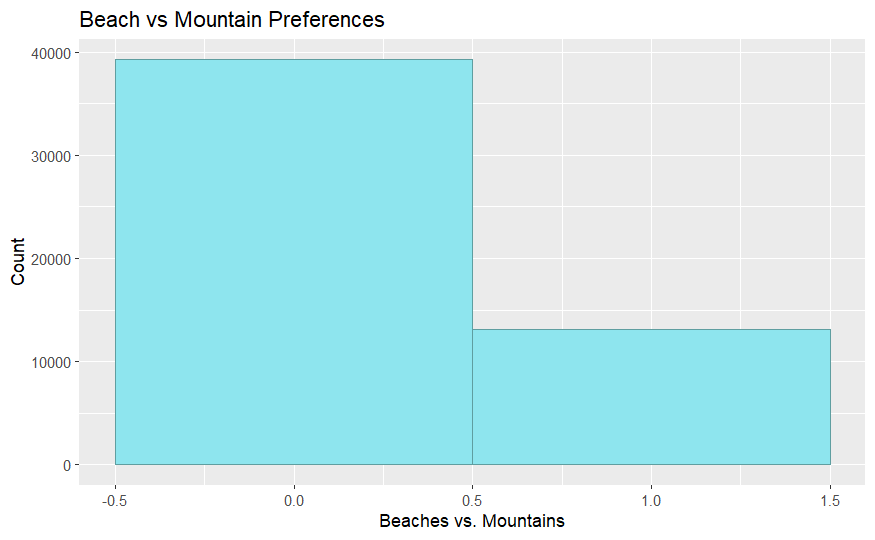

```r
Beach_vs_mountain %>%
  ggplot(aes(x = Preference)) +
  geom_histogram(binwidth = 1, fill = "cadetblue2", color = "cadetblue") +
  labs(
    title = "Beach vs Mountain Preferences",
    x = "Beaches vs. Mountains",
    y = "Count")
```

```r
NA
```

### Description:

> This graph shows the distribution of preference between beaches (0) and mountains (1). It shows a strong preference overall toward beaches. This is particularly interesting due to the rest of the variables being evenly distributed for the most part. Below we will see what variables play a part in the uneven distribution we are seeing here.

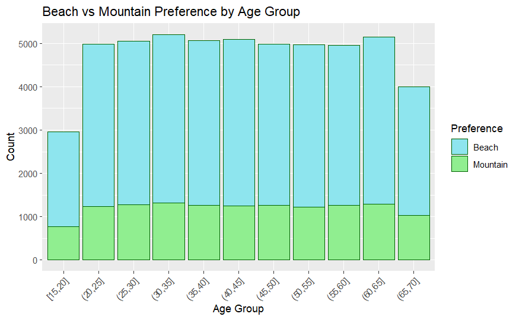

```r
Beach_vs_mountain %>%
mutate(AgeGroup = cut_width(Age, width = 5, boundary = 0)) %>%
  ggplot(aes(x = AgeGroup, fill = factor(Preference))) +
  geom_bar(position = "stack", color = "darkgreen") +
  labs(
    title = "Beach vs Mountain Preference by Age Group",
    x = "Age Group",
    y = "Count",
    fill = "Preference") +
  scale_fill_manual(values = c("cadetblue2", "lightgreen"), labels = c('Beach', 'Mountain')) +
  theme(axis.text.x = element_text(angle = 45, hjust = 1))
```

### Graph Description:

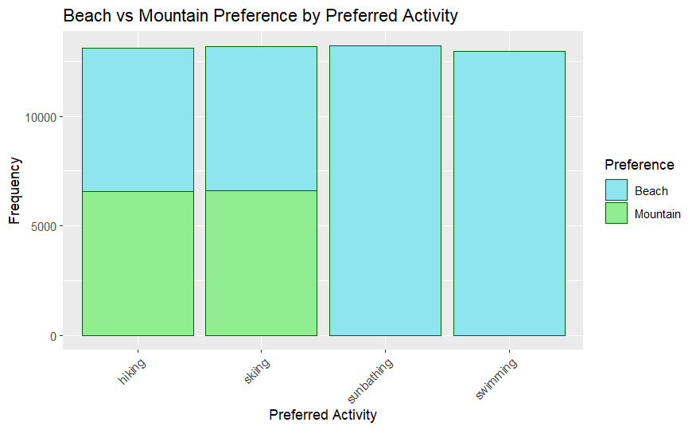

```r
Beach_vs_mountain %>%
  ggplot(aes(x = Preferred_Activities, fill = factor(Preference))) +
  geom_bar(position = "stack", color = "darkgreen") +
  labs(
    title = "Beach vs Mountain Preference by Preferred Activity",
    x = "Preferred Activity",
    y = "Frequency",
    fill = "Preference") +
  scale_fill_manual(values = c("cadetblue2", "lightgreen"), labels = c("Beach", "Mountain")) +
  theme(axis.text.x = element_text(angle = 45, hjust = 1))
```

### Graph Description:

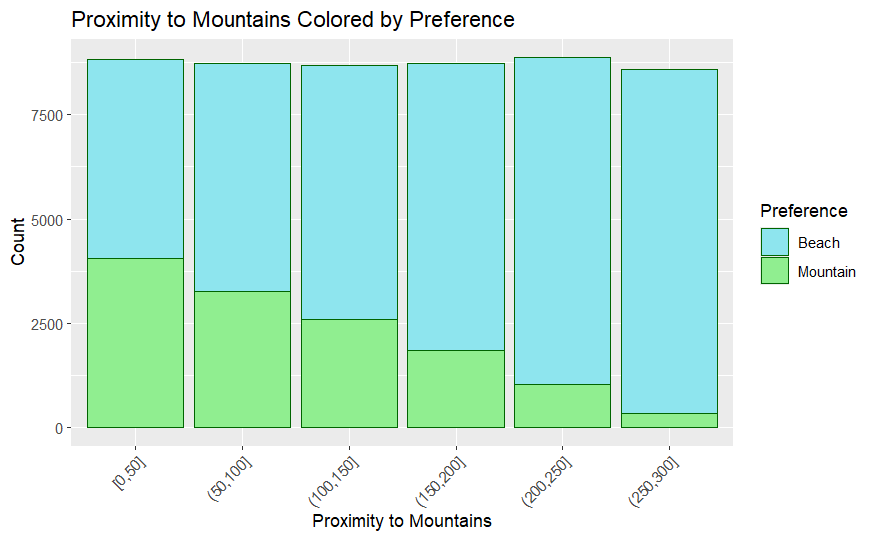

```r
Beach_vs_mountain %>%
mutate(ProximitytoMountainsCut = cut_width(Proximity_to_Mountains, width = 50, boundary = 0)) %>%
  ggplot(aes(x = ProximitytoMountainsCut, fill = factor(Preference))) +
  geom_bar(position = "stack", color = "darkgreen") +
  labs(
    title = "Proximity to Mountains Colored by Preference",
    x = "Proximity to Mountains",
    y = "Count",
  fill = "Preference") +
  scale_fill_manual(values = c("cadetblue2", "lightgreen"), labels = c("Beach", "Mountain")) +
  theme(axis.text.x = element_text(angle = 45, hjust = 1))
```

### Graph Description:

> This shows the distribution of proximity to mountains by preference. Here we can see that as people get further from the mountians they are more likely to prefer the beach. This is important because it shows that proximity to each location does play a factor in the choice between the beach and mountains. It also shows that there is an equal distribution between each proximity.

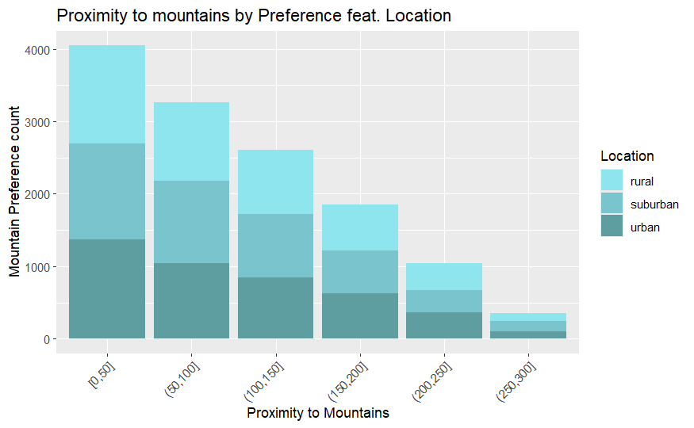

```r
#Prox. to mountains by Preference colored by Location
Beach_vs_mountain %>%
  filter(Preference == '1') %>%
mutate(ProximitytoMountainsCut = cut_width(Proximity_to_Mountains, width = 50, boundary = 0)) %>%
  ggplot(aes(x = ProximitytoMountainsCut, fill = factor(Location))) +
  geom_bar(position = "stack") +
  labs(
    title = "Proximity to mountains by Preference feat. Location",
    x = "Proximity to Mountains",
    y = "Mountain Preference count",
    fill = "Location") +
  scale_fill_manual(values = c("cadetblue2", "cadetblue3", "cadetblue")) +
  theme(axis.text.x = element_text(angle = 45, hjust = 1))
```

### Graph Description

> This graph shows the count of people who prefer the mountains and their proximity to the mountains colored by location type. This tells us that people prefer mountains the closer they are to the mountains. It also shows that there is an equal number of rural, suburban, and urban location for each distance from mountains. This is important because if this dataset was not synthetic we would more than likely have more urban areas not directly in the mountains. This is because it is difficult to create large urban centers in mountain areas leading to more rural locations

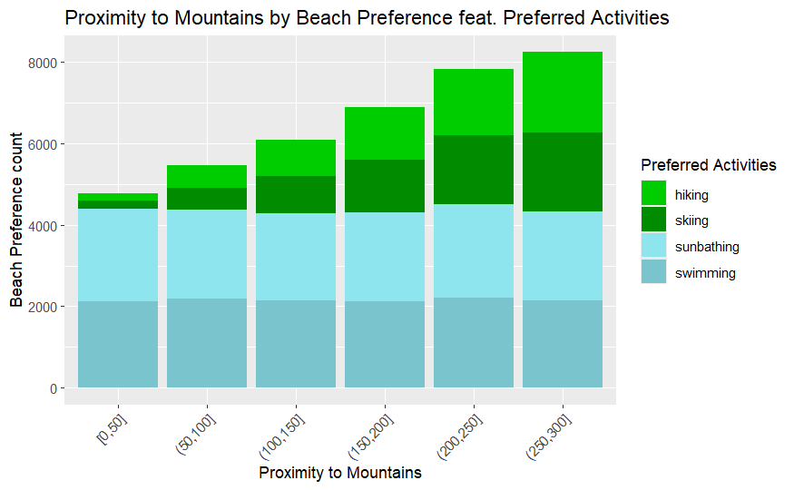

```r
#Graph that shows the relationship between preferred activity proximity and preferred activity colored by preference

#Proximity to mountains by Preference colored by Location
Beach_vs_mountain %>%
  filter(Preference == '0') %>%
mutate(ProximitytoMountainsCut = cut_width(Proximity_to_Mountains, width = 50, boundary = 0)) %>%
  ggplot(aes(x = ProximitytoMountainsCut, fill = factor(Preferred_Activities))) +
  geom_bar(position = "stack") +
  labs(
    title = "Proximity to Mountains by Beach Preference feat. Preferred Activities",
    x = "Proximity to Mountains",
    y = "Beach Preference count",
    fill = "Preferred Activities") +
  scale_fill_manual(values = c("green3", "green4", 'cadetblue2', 'cadetblue3')) +
  theme(axis.text.x = element_text(angle = 45, hjust = 1))
```